# cifar10-image-classification

**IMPORT THE DATSETS AND VIEW RANDOM IMAGES**

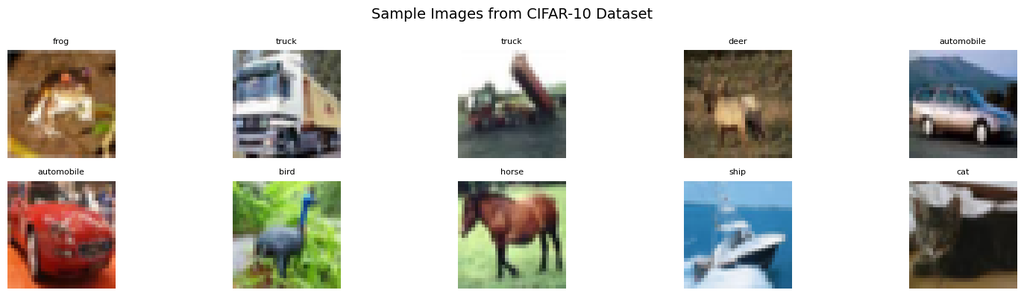

```python
import matplotlib.pyplot as plt
import torchvision
import torchvision.transforms as transforms

# --------------------------------------------------------------
# Step 1: Load CIFAR-10 training and test sets
# --------------------------------------------------------------
transform = transforms.ToTensor()
train_dataset = torchvision.datasets.CIFAR10(root='./data', train=True,
                                             download=True, transform=transform)
test_dataset = torchvision.datasets.CIFAR10(root='./data', train=False,
                                            download=True, transform=transform)

# --------------------------------------------------------------
# Step 2: Retrieve class names
# --------------------------------------------------------------
class_names = train_dataset.classes

# --------------------------------------------------------------
# Step 3: Plot 10 sample images (2 rows × 5 columns)
# --------------------------------------------------------------
fig, axes = plt.subplots(2, 5, figsize=(16, 4))
for i in range(10):
    image, label = train_dataset[i]
    ax = axes[i//5, i%5]
    ax.imshow(image.permute(1, 2, 0))  # Convert from (C, H, W) → (H, W, C)
    ax.set_title(class_names[label], fontsize=8)
    ax.axis('off')

plt.suptitle("Sample Images from CIFAR-10 Dataset", fontsize=14)
plt.tight_layout()
plt.show()
```

**COUNT THE NUMBER OF EACH CLASS IN TRAIN_DATASET**

**All classes have exactly 5000 images — CIFAR-10 is perfectly balanced.**

**This is great for training because we don’t need to worry about class imbalance corrections**

**It sets expectations for how a model should perform across all classes. If we later observe that some classes perform poorly, it’s not due to lack of examples — but perhaps due to class similarity or visual ambiguity.**

```python
from collections import Counter    # import counter

# --------------------------------------------------------------
# Step 1: Get class names directly from dataset
# --------------------------------------------------------------
class_names = train_dataset.classes  # should be 10 items for CIFAR-10

# --------------------------------------------------------------
# Step 2: Extract all labels from the dataset
# --------------------------------------------------------------
labels = [label for _, label in train_dataset]

# --------------------------------------------------------------
# Step 3: Count occurrences of each label
# --------------------------------------------------------------
class_counts = Counter(labels)

# --------------------------------------------------------------
# Step 4: Safely map label indices to class names
# --------------------------------------------------------------
class_counts_named = {
    class_names[k] if k < len(class_names) else f"Unknown_{k}": v
    for k, v in class_counts.items()
}

# --------------------------------------------------------------
# Step 5: Print the class distribution
# --------------------------------------------------------------
print(class_counts_named)
```

```
{'frog': 5000, 'truck': 5000, 'deer': 5000, 'automobile': 5000, 'bird': 5000, 'horse': 5000, 'ship': 5000, 'cat': 5000, 'dog': 5000, 'airplane': 5000}
```

**When we use transforms.ToTensor(), the raw image pixels — originally in the range [0, 255] — are automatically scaled to [0.0, 1.0].**

**This is a form of min-max normalization, and it's crucial for training neural networks.**

**Why Do We Normalize?**

- **Neural networks learn faster when inputs are on a consistent scale**
- **Unnormalized data can cause unstable gradients, especially with large pixel values**
- **Normalized inputs lead to smoother convergence and better training stability**

```python
# --------------------------------------------------------------
# *** Inspect One Image Sample from CIFAR-10 Dataset ***
# --------------------------------------------------------------

# Step 1: Get one image and its label from the training dataset
image, label = train_dataset[0]

# Step 2: Print tensor properties and label details
print(f" Image tensor shape: {image.shape}  # Should be [3, 32, 32]")
print(f" Class index: {label}")
print(f" Class name: {class_names[label]}")
print(f" Min pixel value: {image.min():.4f}")
print(f" Max pixel value: {image.max():.4f}")
```

```
 Image tensor shape: torch.Size([3, 32, 32])  # Should be [3, 32, 32]
 Class index: 6
 Class name: frog
 Min pixel value: 0.0000
 Max pixel value: 1.0000
```

**FLATTENING THE ENTIRE DATASET TO CONVERT THE IMAGES TO 1DIMENSION**

```python
# ==============================================================
#  CIFAR-10 DATASET & TRANSFORM SETUP
# --------------------------------------------------------------
# Converts images to tensors and normalizes each RGB channel.
# CNN models (like AlexNet or LeNet) expect shape: [3, 32, 32]
# ==============================================================

import torchvision
import torchvision.transforms as transforms

# --------------------------------------------------------------
#  Define Transform: Tensor Conversion + Normalization
# --------------------------------------------------------------
transform = transforms.Compose([
    transforms.ToTensor(),  # Convert PIL image to Tensor (C, H, W)
    #transforms.Normalize((0.5, 0.5, 0.5), (0.5, 0.5, 0.5))  # Normalize per channel
    transforms.Lambda(lambda x: x.view(-1))
])

# --------------------------------------------------------------
#  Load CIFAR-10 Training and Test Datasets
# --------------------------------------------------------------
train_dataset = torchvision.datasets.CIFAR10(
    root='./data',
    train=True,
    transform=transform,
    download=True
)

test_dataset = torchvision.datasets.CIFAR10(
    root='./data',
    train=False,
    transform=transform,
    download=True
)

# --------------------------------------------------------------
#  Inspect One Sample
# --------------------------------------------------------------
image, label = train_dataset[0]
print(f" Image shape (for CNN input): {image.shape}")  # Expected: torch.Size([3, 32, 32])
```

```
 Image shape (for CNN input): torch.Size([3072])
```

**Prepare DataLoaders — Train, Validation, and Test**

**Now that our CIFAR-10 dataset is loaded and normalized, we’ll use PyTorch DataLoaders to prepare it for training.**

**torch.utils.data.DataLoader helps with efficient and flexible data loading by:**

- **Batching: Feeds small groups of images (e.g., 64) at each training step**
- **Shuffling: Randomizes the order of samples each epoch to improve generalization**
- **Parallel Loading: Uses multiple workers to load data faster in the background**

**CIFAR-10 provides us with: 50,000 training images and 10,000 test images**

**We'll further split the training set into 45,000 for training and 5,000 for validation**

*** Why This Split?***

**Training set (45K): Used to train the model (weights updated here)**

**Validation set (5K): Used during training to monitor performance and detect overfitting**

**Test set (10K): Held out until the end for final unbiased evaluation**

**Using separate validation and test sets allows us to monitor model behavior during training without contaminating our final performance estimate.**

```python
import torch
from torch.utils.data import DataLoader, random_split

# --------------------------------------------------------------
# *** Define Data Loaders for CIFAR-10 ***
# --------------------------------------------------------------

# Step 1: Set random seed for reproducibility
torch.manual_seed(42)

# Step 2: Define batch size
bs = 64

# Step 3: Split training data into train and validation sets (90/10 split)
train_size = int(0.9 * len(train_dataset))
val_size = len(train_dataset) - train_size

train_data, val_data = random_split(train_dataset, (train_size, val_size))

# Step 4: Create DataLoaders for training, validation, and testing
train_loader = DataLoader(train_data, batch_size=bs, shuffle=True)
val_loader = DataLoader(val_data, batch_size=bs, shuffle=False)
test_loader = DataLoader(test_dataset, batch_size=bs, shuffle=False)

# Step 5: Print dataset batch summary
print(f" Train batches: {len(train_loader)}")
print(f" Validation batches: {len(val_loader)}")
print(f" Test batches: {len(test_loader)}")
```

```
 Train batches: 704
 Validation batches: 79
 Test batches: 157
```

```python
# --------------------------------------------------------------
#  Inspect One Batch from the Training DataLoader
# --------------------------------------------------------------
for images, labels in train_loader:
    # Step 1: Print shape of the image batch (flattened tensors)
    print(f" Batch shape: {images.shape}")   # Expected: [batch_size, 3072]

    # Step 2: Print shape of the label batch
    print(f" Labels shape: {labels.shape}")  # Expected: [batch_size]

    # Step 3: Exit after first batch
    break
```

```
 Batch shape: torch.Size([64, 3072])
 Labels shape: torch.Size([64])
```

**BUILDING THE SIMPLE MODEL ARCHITECTURE**

```python
# ==============================================================
# 🧠 IMAGE CLASSIFICATION MODEL DEFINITION (Fully Connected Network)
# ==============================================================

import torch.nn as nn


# --------------------------------------------------------------
#  Define a simple feedforward neural network for image data
# --------------------------------------------------------------
class ImageModel(nn.Module):
    def __init__(self, input_dim=3072, hidden_dim=128, output_dim=10):
        super(ImageModel, self).__init__()

        # --------------------------------------------------------------
        #  Network Architecture
        # --------------------------------------------------------------
        self.net = nn.Sequential(
            nn.Linear(input_dim, hidden_dim),  # Layer 1: Input → Hidden
            nn.ReLU(),                         # Activation: ReLU
            nn.Linear(hidden_dim, output_dim)   # Layer 2: Hidden → Output
        )

    # --------------------------------------------------------------
    #  Forward Pass
    # --------------------------------------------------------------
    def forward(self, x):
        return self.net(x)


# --------------------------------------------------------------
#  Initialize and Inspect the Model
# --------------------------------------------------------------
model_norm = ImageModel()
print(model_norm)
```

```
ImageModel(
  (net): Sequential(
    (0): Linear(in_features=3072, out_features=128, bias=True)
    (1): ReLU()
    (2): Linear(in_features=128, out_features=10, bias=True)
  )
)
```

**Training the Image_model on CIFAR-10**

**We now train our Image model using:**

- **Loss: CrossEntropyLoss, ideal for multiclass classification.**
- **Optimizer: Adam, a widely used optimizer combining momentum and adaptive learning rates.**
- **Epochs: We'll train for a few epochs and observe the trends in loss and accuracy.**

**Key Concepts**

**Loss Function: We use nn.CrossEntropyLoss which combines log-softmax and negative log-likelihood. It expects raw logits as model output and integer class labels as targets**

**Optimizer: We use Adam for efficiency and stability. We'll update weights based on gradients computed by backpropagation.**

**Metrics: We’ll track Training loss (average per epoch) and Training accuracy (proportion of correct predictions).**

```python
# --------------------------------------------------------------
# *** CIFAR-10 Model Training with Adam Optimizer ***
# --------------------------------------------------------------

import torch
import torch.optim as optim
import torch.nn as nn

# --------------------------------------------------------------
# *** Device Configuration ***
# --------------------------------------------------------------
device = torch.device("cuda" if torch.cuda.is_available() else "cpu")
model_norm.to(device)

# --------------------------------------------------------------
# *** Loss Function and Optimizer ***
# --------------------------------------------------------------
criterion = nn.CrossEntropyLoss()
optimizer = optim.Adam(model_norm.parameters(), lr=0.001)

# --------------------------------------------------------------
# *** Training Loop ***
# --------------------------------------------------------------
epochs = 100
train_acc = []
train_losses = []

for epoch in range(epochs):
    model_norm.train()
    running_loss = 0.0
    correct = 0
    total = 0

    # ----------------------------------------------------------
    # *** Batch Iteration ***
    # ----------------------------------------------------------
    for images, labels in train_loader:
        images, labels = images.to(device), labels.to(device)

        # Forward Pass
        outputs = model_norm(images)
        loss = criterion(outputs, labels)

        # Backward Pass
        optimizer.zero_grad()
        loss.backward()
        optimizer.step()

        # Statistics
        running_loss += loss.item() * images.size(0)
        _, predicted = torch.max(outputs, 1)
        correct += (predicted == labels).sum().item()
        total += labels.size(0)

    # ----------------------------------------------------------
    # *** Epoch Metrics ***
    # ----------------------------------------------------------
    epoch_loss = running_loss / total
    epoch_acc = correct / total
    train_losses.append(epoch_loss)
    train_acc.append(epoch_acc)

    # ----------------------------------------------------------
    # *** Progress Log ***
    # ----------------------------------------------------------

    if (epoch + 1)% 20 == 0:
        print(f"Epoch [{epoch + 1}/{epochs}] | Loss: {epoch_loss:.4f} | Accuracy: {epoch_acc:.4f}")
```

```
Epoch [20/100] | Loss: 1.4195 | Accuracy: 0.4996
Epoch [40/100] | Loss: 1.3499 | Accuracy: 0.5213
Epoch [60/100] | Loss: 1.3008 | Accuracy: 0.5375
Epoch [80/100] | Loss: 1.2781 | Accuracy: 0.5447
Epoch [100/100] | Loss: 1.2454 | Accuracy: 0.5592
```

**After 100 epochs, here’s what we observed:**

**The model is learning steadily — loss is decreasing and accuracy is improving. But performance is still far from ideal. With only one hidden layer and no spatial awareness, it’s expected that:**

**The MLP struggles to capture image structure (e.g., edges, shapes, textures)**

**It treats pixels as independent features, which is suboptimal for images**

**The model is underfitting, though improving**

**🔧 What Can Help?**

**Deeper MLPs (more hidden layers)**

**Better optimizers or learning rate tuning**

**Convolutional Neural Networks (CNNs) — designed to leverage spatial locality**

**EVALUATION ON TEST SET**

[output not shown]

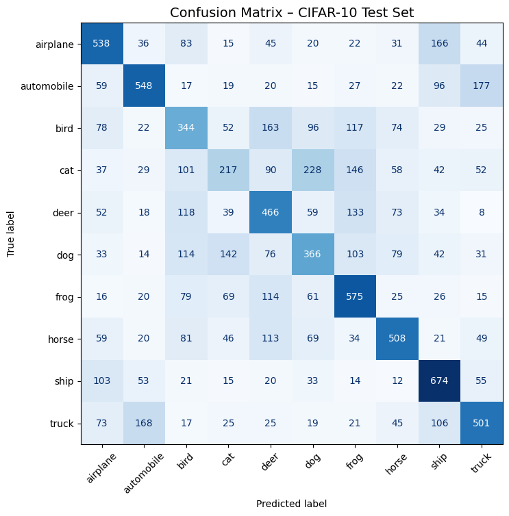

```
 *** Classification Report – CIFAR-10 Test Set ***

              precision    recall  f1-score   support

    airplane       0.51      0.54      0.53      1000
  automobile       0.59      0.55      0.57      1000
        bird       0.35      0.34      0.35      1000
         cat       0.34      0.22      0.26      1000
        deer       0.41      0.47      0.44      1000
         dog       0.38      0.37      0.37      1000
        frog       0.48      0.57      0.52      1000
       horse       0.55      0.51      0.53      1000
        ship       0.55      0.67      0.60      1000
       truck       0.52      0.50      0.51      1000

    accuracy                           0.47     10000
   macro avg       0.47      0.47      0.47     10000
weighted avg       0.47      0.47      0.47     10000
```

```python
# --------------------------------------------------------------
# *** CIFAR-10 Model Evaluation: Accuracy, Confusion Matrix & Classification Report ***
# --------------------------------------------------------------

from sklearn.metrics import (
    confusion_matrix,
    ConfusionMatrixDisplay,
    accuracy_score, f1_score, recall_score
    classification_report
)
import matplotlib.pyplot as plt
import torch

# --------------------------------------------------------------
# *** Switch Model to Evaluation Mode ***
# --------------------------------------------------------------
model_norm.eval()

# --------------------------------------------------------------
# *** Collect Predictions and True Labels ***
# --------------------------------------------------------------
all_preds = []
all_labels = []

with torch.no_grad():
    for images, labels in test_loader:
        images = images.to(device)
        labels = labels.to(device)

        outputs = model_norm(images)
        _, predicted = torch.max(outputs, 1)

        all_preds.extend(predicted.cpu().numpy())
        all_labels.extend(labels.cpu().numpy())

# --------------------------------------------------------------
# *** Compute Test Accuracy ***
# --------------------------------------------------------------
test_accuracy = accuracy_score(all_labels, all_preds)
test_f1 = f1_score(all_labels, all_preds)
test_recall = recall_score(all_labels, all_preds)
print(f"\n Test Accuracy: {test_accuracy:.4f}")
print(f"\n Test Recall : {test_recall}")
print(f"\n Test f1 : {test_f1}")

# --------------------------------------------------------------
# *** Confusion Matrix Visualization ***
# --------------------------------------------------------------
cm = confusion_matrix(all_labels, all_preds)
disp = ConfusionMatrixDisplay(confusion_matrix=cm, display_labels=class_names)

fig, ax = plt.subplots(figsize=(10, 8))
disp.plot(ax=ax, cmap='Blues', xticks_rotation=45, colorbar=False)
plt.title("Confusion Matrix – CIFAR-10 Test Set", fontsize=14)
plt.show()

# --------------------------------------------------------------
# *** Detailed Classification Report ***
# --------------------------------------------------------------
report = classification_report(all_labels, all_preds, target_names=class_names)
print("\n *** Classification Report – CIFAR-10 Test Set ***\n")
print(report)
```

**DEEP NEURAL NETWORK WITH RECTIFIED LINEAR UNIT (RELU)**

```python
# --------------------------------------------------------------
# Task 2 – Define and Inspect Deep MLP Model (5 Hidden Layers)
# --------------------------------------------------------------

import torch
import torch.nn as nn

# Define the deep MLP model
class Deep_model_Relu(nn.Module):
    def __init__(self, input_dim=3072, hidden_dim=128, output_dim=10):
        super(Deep_model_Relu, self).__init__()
        self.network = nn.Sequential(
            nn.Linear(input_dim, hidden_dim),
            nn.ReLU(),
            nn.Linear(hidden_dim, hidden_dim),
            nn.ReLU(),
            nn.Linear(hidden_dim, hidden_dim),
            nn.ReLU(),
            nn.Linear(hidden_dim, hidden_dim),
            nn.ReLU(),
            nn.Linear(hidden_dim, hidden_dim),
            nn.ReLU(),
            nn.Linear(hidden_dim, output_dim)   # Output layer (10 classes for CIFAR-10)
        )

    def forward(self, x):
        return self.network(x)

# Instantiate the model
deep_model = Deep_model_Relu()

# Print model architecture
print(deep_model)

# Count total trainable parameters
total_params = sum(p.numel() for p in deep_model.parameters() if p.requires_grad)
print("Total trainable parameters:", total_params)
```

```
Deep_model_Relu(
  (network): Sequential(
    (0): Linear(in_features=3072, out_features=128, bias=True)
    (1): ReLU()
    (2): Linear(in_features=128, out_features=128, bias=True)
    (3): ReLU()
    (4): Linear(in_features=128, out_features=128, bias=True)
    (5): ReLU()
    (6): Linear(in_features=128, out_features=128, bias=True)
    (7): ReLU()
    (8): Linear(in_features=128, out_features=128, bias=True)
    (9): ReLU()
    (10): Linear(in_features=128, out_features=10, bias=True)
  )
)
Total trainable parameters: 460682
```

**TRAIN DEEP MODEL FUNCTION**

```python
# --------------------------------------------------------------
# Task 3 – Train Deep MLP Model (with Training & Validation Loops)
# --------------------------------------------------------------

import torch
import torch.nn as nn

def train_deep_model(model, train_loader, val_loader, epochs=100, lr=0.001):

    # Set random seed for reproducibility
    torch.manual_seed(42)

    # Device configuration
    device = torch.device("cuda" if torch.cuda.is_available() else "cpu")
    model = model.to(device)

    # Define optimizer and loss function
    optimizer = torch.optim.Adam(model.parameters(), lr=lr)
    criterion = nn.CrossEntropyLoss()

    # Lists to store metrics
    train_loss_list, val_loss_list = [], []
    train_acc_list, val_acc_list = [], []

    # Training loop
    for epoch in range(epochs):
        model.train()
        running_loss, correct, total = 0.0, 0, 0

        for images, labels in train_loader:
            images, labels = images.to(device), labels.to(device)

            optimizer.zero_grad()
            outputs = model(images)
            loss = criterion(outputs, labels)
            loss.backward()
            optimizer.step()

            running_loss += loss.item() * images.size(0)
            _, predicted = torch.max(outputs, 1)
            total += labels.size(0)
            correct += (predicted == labels).sum().item()

        # Compute average training metrics
        train_loss = running_loss / total
        train_accuracy = correct / total
        train_loss_list.append(train_loss)
        train_acc_list.append(train_accuracy)

        # ----------------------------------------------------------
        # Validation phase
        # ----------------------------------------------------------
        model.eval()
        val_loss, val_correct, val_total = 0.0, 0, 0

        with torch.no_grad():
            for images, labels in val_loader:
                images, labels = images.to(device), labels.to(device)
                outputs = model(images)
                loss = criterion(outputs, labels)

                val_loss += loss.item() * images.size(0)
                _, predicted = torch.max(outputs, 1)
                val_total += labels.size(0)
                val_correct += (predicted == labels).sum().item()

        val_loss /= val_total
        val_acc = val_correct / val_total
        val_loss_list.append(val_loss)
        val_acc_list.append(val_acc)

        # ----------------------------------------------------------
        # Progress log
        # ----------------------------------------------------------
        print(f"Epoch [{epoch + 1}/{epochs}] | "
              f"Train Acc: {train_accuracy:.4f} | Train Loss: {train_loss:.4f} | "
              f"Val Acc: {val_acc:.4f} | Val Loss: {val_loss:.4f}")

    return train_loss_list, val_loss_list, train_acc_list, val_acc_list
```

```python
# --------------------------------------------------------------
#    Train the Deep MLP Model and Store Training Results
# --------------------------------------------------------------

# Train the model
train_losses, val_losses, train_accuracy, val_accuracy = train_deep_model(
    deep_model,
    train_loader,
    val_loader,
    epochs=50,
    lr=0.001
)

# --------------------------------------------------------------
#  Verify output lengths
# --------------------------------------------------------------
print("\nTraining complete!")
print("Length of train losses:", len(train_losses))
print("Length of validation losses:", len(val_losses))
print("Length of train accuracy:", len(train_accuracy))
print("Length of validation accuracy:", len(val_accuracy))
```

```
Epoch [1/50] | Train Acc: 0.2712 | Train Loss: 1.9559 | Val Acc: 0.3326 | Val Loss: 1.8172
Epoch [2/50] | Train Acc: 0.3589 | Train Loss: 1.7610 | Val Acc: 0.3698 | Val Loss: 1.7709
Epoch [3/50] | Train Acc: 0.3938 | Train Loss: 1.6788 | Val Acc: 0.4044 | Val Loss: 1.6271
Epoch [4/50] | Train Acc: 0.4201 | Train Loss: 1.6124 | Val Acc: 0.4096 | Val Loss: 1.6497
Epoch [5/50] | Train Acc: 0.4342 | Train Loss: 1.5691 | Val Acc: 0.3992 | Val Loss: 1.6687
Epoch [6/50] | Train Acc: 0.4438 | Train Loss: 1.5378 | Val Acc: 0.4414 | Val Loss: 1.5610
Epoch [7/50] | Train Acc: 0.4555 | Train Loss: 1.5065 | Val Acc: 0.4564 | Val Loss: 1.5174
Epoch [8/50] | Train Acc: 0.4683 | Train Loss: 1.4761 | Val Acc: 0.4462 | Val Loss: 1.5425
Epoch [9/50] | Train Acc: 0.4763 | Train Loss: 1.4540 | Val Acc: 0.4596 | Val Loss: 1.5083
Epoch [10/50] | Train Acc: 0.4880 | Train Loss: 1.4291 | Val Acc: 0.4510 | Val Loss: 1.5084
Epoch [11/50] | Train Acc: 0.4912 | Train Loss: 1.4088 | Val Acc: 0.4518 | Val Loss: 1.5343
Epoch [12/50] | Train Acc: 0.5001 | Train Loss: 1.3842 | Val Acc: 0.4702 | Val Loss: 1.4658
Epoch [13/50] | Train Acc: 0.5055 | Train Loss: 1.3711 | Val Acc: 0.4564 | Val Loss: 1.5277
Epoch [14/50] | Train Acc: 0.5097 | Train Loss: 1.3565 | Val Acc: 0.4780 | Val Loss: 1.4647
Epoch [15/50] | Train Acc: 0.5177 | Train Loss: 1.3393 | Val Acc: 0.4656 | Val Loss: 1.4955
Epoch [16/50] | Train Acc: 0.5232 | Train Loss: 1.3165 | Val Acc: 0.4860 | Val Loss: 1.4533
Epoch [17/50] | Train Acc: 0.5289 | Train Loss: 1.3063 | Val Acc: 0.4730 | Val Loss: 1.4883
Epoch [18/50] | Train Acc: 0.5344 | Train Loss: 1.2905 | Val Acc: 0.4746 | Val Loss: 1.4807
Epoch [19/50] | Train Acc: 0.5390 | Train Loss: 1.2754 | Val Acc: 0.4866 | Val Loss: 1.4582
Epoch [20/50] | Train Acc: 0.5446 | Train Loss: 1.2594 | Val Acc: 0.4816 | Val Loss: 1.4622
Epoch [21/50] | Train Acc: 0.5485 | Train Loss: 1.2507 | Val Acc: 0.4806 | Val Loss: 1.4832
Epoch [22/50] | Train Acc: 0.5552 | Train Loss: 1.2301 | Val Acc: 0.4792 | Val Loss: 1.5037
Epoch [23/50] | Train Acc: 0.5589 | Train Loss: 1.2209 | Val Acc: 0.4842 | Val Loss: 1.4766
Epoch [24/50] | Train Acc: 0.5638 | Train Loss: 1.2037 | Val Acc: 0.4902 | Val Loss: 1.4805
Epoch [25/50] | Train Acc: 0.5667 | Train Loss: 1.1938 | Val Acc: 0.4740 | Val Loss: 1.5119
Epoch [26/50] | Train Acc: 0.5700 | Train Loss: 1.1823 | Val Acc: 0.4766 | Val Loss: 1.5270
Epoch [27/50] | Train Acc: 0.5787 | Train Loss: 1.1608 | Val Acc: 0.4946 | Val Loss: 1.4711
Epoch [28/50] | Train Acc: 0.5812 | Train Loss: 1.1522 | Val Acc: 0.4850 | Val Loss: 1.5070
Epoch [29/50] | Train Acc: 0.5826 | Train Loss: 1.1420 | Val Acc: 0.4692 | Val Loss: 1.5727
Epoch [30/50] | Train Acc: 0.5865 | Train Loss: 1.1367 | Val Acc: 0.4894 | Val Loss: 1.5117
Epoch [31/50] | Train Acc: 0.5933 | Train Loss: 1.1188 | Val Acc: 0.4836 | Val Loss: 1.5097
Epoch [32/50] | Train Acc: 0.5991 | Train Loss: 1.1046 | Val Acc: 0.4868 | Val Loss: 1.5481
Epoch [33/50] | Train Acc: 0.6007 | Train Loss: 1.0974 | Val Acc: 0.4948 | Val Loss: 1.5552
Epoch [34/50] | Train Acc: 0.6019 | Train Loss: 1.0890 | Val Acc: 0.4904 | Val Loss: 1.5471
Epoch [35/50] | Train Acc: 0.6065 | Train Loss: 1.0770 | Val Acc: 0.4784 | Val Loss: 1.5515
Epoch [36/50] | Train Acc: 0.6137 | Train Loss: 1.0589 | Val Acc: 0.4782 | Val Loss: 1.6148
Epoch [37/50] | Train Acc: 0.6169 | Train Loss: 1.0494 | Val Acc: 0.4834 | Val Loss: 1.6051
Epoch [38/50] | Train Acc: 0.6192 | Train Loss: 1.0381 | Val Acc: 0.4842 | Val Loss: 1.6063
Epoch [39/50] | Train Acc: 0.6209 | Train Loss: 1.0311 | Val Acc: 0.4728 | Val Loss: 1.6722
Epoch [40/50] | Train Acc: 0.6280 | Train Loss: 1.0195 | Val Acc: 0.4790 | Val Loss: 1.6557
Epoch [41/50] | Train Acc: 0.6270 | Train Loss: 1.0177 | Val Acc: 0.4788 | Val Loss: 1.6270
Epoch [42/50] | Train Acc: 0.6305 | Train Loss: 1.0092 | Val Acc: 0.4818 | Val Loss: 1.6657
Epoch [43/50] | Train Acc: 0.6362 | Train Loss: 0.9915 | Val Acc: 0.4796 | Val Loss: 1.6543
Epoch [44/50] | Train Acc: 0.6388 | Train Loss: 0.9871 | Val Acc: 0.4890 | Val Loss: 1.6980
Epoch [45/50] | Train Acc: 0.6438 | Train Loss: 0.9740 | Val Acc: 0.4680 | Val Loss: 1.7674
Epoch [46/50] | Train Acc: 0.6462 | Train Loss: 0.9681 | Val Acc: 0.4822 | Val Loss: 1.6994
Epoch [47/50] | Train Acc: 0.6501 | Train Loss: 0.9571 | Val Acc: 0.4764 | Val Loss: 1.6934
Epoch [48/50] | Train Acc: 0.6492 | Train Loss: 0.9512 | Val Acc: 0.4564 | Val Loss: 1.8147
Epoch [49/50] | Train Acc: 0.6583 | Train Loss: 0.9296 | Val Acc: 0.4724 | Val Loss: 1.7724
Epoch [50/50] | Train Acc: 0.6565 | Train Loss: 0.9318 | Val Acc: 0.4798 | Val Loss: 1.7256

Training complete!
Length of train losses: 50
Length of validation losses: 50
Length of train accuracy: 50
Length of validation accuracy: 50
```

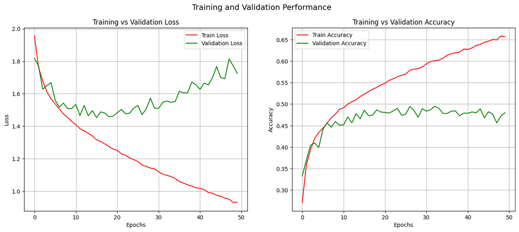

```python
# --------------------------------------------------------------
# Task 5 – Visualize Training and Validation Performance
# --------------------------------------------------------------

import matplotlib.pyplot as plt

plt.figure(figsize=(16, 6))

# -----------------------------
# Plot Training & Validation Loss
# -----------------------------
plt.subplot(1, 2, 1)
plt.plot(train_losses, label='Train Loss', color='red')
plt.plot(val_losses, label='Validation Loss', color='green')
plt.xlabel('Epochs')
plt.ylabel('Loss')
plt.title('Training vs Validation Loss')
plt.legend()
plt.grid(True)

# -----------------------------
# Plot Training & Validation Accuracy
# -----------------------------
plt.subplot(1, 2, 2)
plt.plot(train_accuracy, label='Train Accuracy', color='red')
plt.plot(val_accuracy, label='Validation Accuracy', color='green')
plt.xlabel('Epochs')
plt.ylabel('Accuracy')
plt.title('Training vs Validation Accuracy')
plt.legend()
plt.grid(True)

# -----------------------------
# Overall Title
# -----------------------------
plt.suptitle('Training and Validation Performance', fontsize=14)
plt.show()
```

[output not shown]

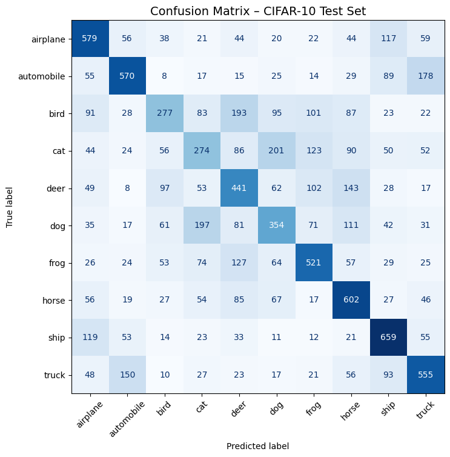

```
 *** Classification Report – CIFAR-10 Test Set ***

              precision    recall  f1-score   support

    airplane       0.53      0.58      0.55      1000
  automobile       0.60      0.57      0.58      1000
        bird       0.43      0.28      0.34      1000
         cat       0.33      0.27      0.30      1000
        deer       0.39      0.44      0.41      1000
         dog       0.39      0.35      0.37      1000
        frog       0.52      0.52      0.52      1000
       horse       0.49      0.60      0.54      1000
        ship       0.57      0.66      0.61      1000
       truck       0.53      0.56      0.54      1000

    accuracy                           0.48     10000
   macro avg       0.48      0.48      0.48     10000
weighted avg       0.48      0.48      0.48     10000
```

```python
# --------------------------------------------------------------
# *** CIFAR-10 Model Evaluation: Accuracy, Confusion Matrix & Classification Report ***
# --------------------------------------------------------------

from sklearn.metrics import (
    confusion_matrix,
    ConfusionMatrixDisplay,
    accuracy_score, recall_score, f1_score
    classification_report
)
import matplotlib.pyplot as plt
import torch

# --------------------------------------------------------------
# *** Switch Model to Evaluation Mode ***
# --------------------------------------------------------------
deep_model.eval()

# --------------------------------------------------------------
# *** Collect Predictions and True Labels ***
# --------------------------------------------------------------
all_preds = []
all_labels = []

with torch.no_grad():
    for images, labels in test_loader:
        images = images.to(device)
        labels = labels.to(device)

        outputs = deep_model(images)
        _, predicted = torch.max(outputs, 1)

        all_preds.extend(predicted.cpu().numpy())
        all_labels.extend(labels.cpu().numpy())

# --------------------------------------------------------------
# *** Compute Test Accuracy ***
# --------------------------------------------------------------
test_accuracy = accuracy_score(all_labels, all_preds)
test_f1 = f1_score(all_labels, all_preds)
test_recall = recall_score(all_labels, all_preds)
print(f"\n Test Accuracy: {test_accuracy:.4f}")
print(f"\n Test Recall : {test_recall}")
print(f"\n Test f1 : {test_f1}")
# --------------------------------------------------------------
# *** Confusion Matrix Visualization ***
# --------------------------------------------------------------
cm = confusion_matrix(all_labels, all_preds)
disp = ConfusionMatrixDisplay(confusion_matrix=cm, display_labels=class_names)

fig, ax = plt.subplots(figsize=(10, 8))
disp.plot(ax=ax, cmap='Blues', xticks_rotation=45, colorbar=False)
plt.title("Confusion Matrix – CIFAR-10 Test Set", fontsize=14)
plt.show()

# --------------------------------------------------------------
# *** Detailed Classification Report ***
# --------------------------------------------------------------
report = classification_report(all_labels, all_preds, target_names=class_names)
print("\n *** Classification Report – CIFAR-10 Test Set ***\n")
print(report)
```

```python
# --------------------------------------------------------------
# Task 2 – Define and Inspect Deep MLP Model (5 Hidden Layers)
# --------------------------------------------------------------

import torch
import torch.nn as nn

# Define the deep MLP model
class Deep_model_tanh(nn.Module):
    def __init__(self, input_dim=3072, hidden_dim=128, output_dim=10):
        super(Deep_model_tanh, self).__init__()
        self.network = nn.Sequential(
            nn.Linear(input_dim, hidden_dim),
            nn.Tanh(),
            nn.Linear(hidden_dim, hidden_dim),
            nn.Tanh(),
            nn.Linear(hidden_dim, hidden_dim),
            nn.Tanh(),
            nn.Linear(hidden_dim, hidden_dim),
            nn.Tanh(),
            nn.Linear(hidden_dim, hidden_dim),
            nn.Tanh(),
            nn.Linear(hidden_dim, output_dim)   # Output layer (10 classes for CIFAR-10)
        )

    def forward(self, x):
        return self.network(x)

# Instantiate the model
deep_model_tanh = Deep_model_tanh()

# Print model architecture
print(deep_model_tanh)

# Count total trainable parameters
total_params = sum(p.numel() for p in deep_model.parameters() if p.requires_grad)
print("Total trainable parameters:", total_params)
```

```
Deep_model_tanh(
  (network): Sequential(
    (0): Linear(in_features=3072, out_features=128, bias=True)
    (1): Tanh()
    (2): Linear(in_features=128, out_features=128, bias=True)
    (3): Tanh()
    (4): Linear(in_features=128, out_features=128, bias=True)
    (5): Tanh()
    (6): Linear(in_features=128, out_features=128, bias=True)
    (7): Tanh()
    (8): Linear(in_features=128, out_features=128, bias=True)
    (9): Tanh()
    (10): Linear(in_features=128, out_features=10, bias=True)
  )
)
Total trainable parameters: 460682
```

```python
# --------------------------------------------------------------
# *** Train Deep MLP Model with Tanh Activation ***
# --------------------------------------------------------------
tanh_train_losses, tanh_val_losses, tanh_train_accuracies, tanh_val_accuracies = train_deep_model(
    model=deep_model_tanh,    # Deep MLP using Tanh activations
    train_loader=train_loader,
    val_loader=val_loader,
    epochs=50                  # Number of epochs to train
)
```

```
Epoch [1/50] | Train Acc: 0.2646 | Train Loss: 1.9805 | Val Acc: 0.2816 | Val Loss: 1.9762
Epoch [2/50] | Train Acc: 0.3076 | Train Loss: 1.8870 | Val Acc: 0.2992 | Val Loss: 1.9012
Epoch [3/50] | Train Acc: 0.3280 | Train Loss: 1.8499 | Val Acc: 0.3314 | Val Loss: 1.8373
Epoch [4/50] | Train Acc: 0.3399 | Train Loss: 1.8250 | Val Acc: 0.3352 | Val Loss: 1.8472
Epoch [5/50] | Train Acc: 0.3505 | Train Loss: 1.7996 | Val Acc: 0.3252 | Val Loss: 1.8672
Epoch [6/50] | Train Acc: 0.3546 | Train Loss: 1.7852 | Val Acc: 0.3430 | Val Loss: 1.8061
Epoch [7/50] | Train Acc: 0.3642 | Train Loss: 1.7599 | Val Acc: 0.3552 | Val Loss: 1.8016
Epoch [8/50] | Train Acc: 0.3680 | Train Loss: 1.7530 | Val Acc: 0.3438 | Val Loss: 1.8264
Epoch [9/50] | Train Acc: 0.3703 | Train Loss: 1.7444 | Val Acc: 0.3710 | Val Loss: 1.7620
Epoch [10/50] | Train Acc: 0.3724 | Train Loss: 1.7393 | Val Acc: 0.3684 | Val Loss: 1.7688
Epoch [11/50] | Train Acc: 0.3784 | Train Loss: 1.7186 | Val Acc: 0.3622 | Val Loss: 1.7582
Epoch [12/50] | Train Acc: 0.3813 | Train Loss: 1.7128 | Val Acc: 0.3650 | Val Loss: 1.7422
Epoch [13/50] | Train Acc: 0.3847 | Train Loss: 1.7069 | Val Acc: 0.3452 | Val Loss: 1.8214
Epoch [14/50] | Train Acc: 0.3896 | Train Loss: 1.6946 | Val Acc: 0.3850 | Val Loss: 1.7104
Epoch [15/50] | Train Acc: 0.3941 | Train Loss: 1.6887 | Val Acc: 0.3752 | Val Loss: 1.7642
Epoch [16/50] | Train Acc: 0.3963 | Train Loss: 1.6781 | Val Acc: 0.3836 | Val Loss: 1.7232
Epoch [17/50] | Train Acc: 0.3986 | Train Loss: 1.6790 | Val Acc: 0.3804 | Val Loss: 1.7514
Epoch [18/50] | Train Acc: 0.3992 | Train Loss: 1.6695 | Val Acc: 0.3810 | Val Loss: 1.7030
Epoch [19/50] | Train Acc: 0.4037 | Train Loss: 1.6540 | Val Acc: 0.3808 | Val Loss: 1.7114
Epoch [20/50] | Train Acc: 0.4008 | Train Loss: 1.6558 | Val Acc: 0.3908 | Val Loss: 1.7165
Epoch [21/50] | Train Acc: 0.4033 | Train Loss: 1.6569 | Val Acc: 0.3772 | Val Loss: 1.7326
Epoch [22/50] | Train Acc: 0.4055 | Train Loss: 1.6501 | Val Acc: 0.3896 | Val Loss: 1.7340
Epoch [23/50] | Train Acc: 0.4080 | Train Loss: 1.6481 | Val Acc: 0.3828 | Val Loss: 1.7110
Epoch [24/50] | Train Acc: 0.4141 | Train Loss: 1.6295 | Val Acc: 0.3922 | Val Loss: 1.7114
Epoch [25/50] | Train Acc: 0.4112 | Train Loss: 1.6309 | Val Acc: 0.4170 | Val Loss: 1.6737
Epoch [26/50] | Train Acc: 0.4142 | Train Loss: 1.6252 | Val Acc: 0.3728 | Val Loss: 1.7430
Epoch [27/50] | Train Acc: 0.4145 | Train Loss: 1.6272 | Val Acc: 0.3762 | Val Loss: 1.7176
Epoch [28/50] | Train Acc: 0.4172 | Train Loss: 1.6169 | Val Acc: 0.4082 | Val Loss: 1.6761
Epoch [29/50] | Train Acc: 0.4164 | Train Loss: 1.6132 | Val Acc: 0.4042 | Val Loss: 1.6550
Epoch [30/50] | Train Acc: 0.4214 | Train Loss: 1.6060 | Val Acc: 0.4020 | Val Loss: 1.6603
Epoch [31/50] | Train Acc: 0.4190 | Train Loss: 1.6117 | Val Acc: 0.4018 | Val Loss: 1.6717
Epoch [32/50] | Train Acc: 0.4197 | Train Loss: 1.6159 | Val Acc: 0.3970 | Val Loss: 1.6893
Epoch [33/50] | Train Acc: 0.4203 | Train Loss: 1.6073 | Val Acc: 0.3816 | Val Loss: 1.6825
Epoch [34/50] | Train Acc: 0.4064 | Train Loss: 1.6559 | Val Acc: 0.3850 | Val Loss: 1.7192
Epoch [35/50] | Train Acc: 0.4183 | Train Loss: 1.6226 | Val Acc: 0.3926 | Val Loss: 1.6821
Epoch [36/50] | Train Acc: 0.4138 | Train Loss: 1.6248 | Val Acc: 0.3914 | Val Loss: 1.6840
Epoch [37/50] | Train Acc: 0.4160 | Train Loss: 1.6145 | Val Acc: 0.4004 | Val Loss: 1.7051
Epoch [38/50] | Train Acc: 0.4226 | Train Loss: 1.6049 | Val Acc: 0.4118 | Val Loss: 1.6582
Epoch [39/50] | Train Acc: 0.4225 | Train Loss: 1.6052 | Val Acc: 0.3818 | Val Loss: 1.7204
Epoch [40/50] | Train Acc: 0.4228 | Train Loss: 1.5968 | Val Acc: 0.3970 | Val Loss: 1.6794
Epoch [41/50] | Train Acc: 0.4229 | Train Loss: 1.6072 | Val Acc: 0.3968 | Val Loss: 1.6928
Epoch [42/50] | Train Acc: 0.4279 | Train Loss: 1.5931 | Val Acc: 0.4094 | Val Loss: 1.6746
Epoch [43/50] | Train Acc: 0.4262 | Train Loss: 1.5966 | Val Acc: 0.4048 | Val Loss: 1.6939
Epoch [44/50] | Train Acc: 0.4280 | Train Loss: 1.5888 | Val Acc: 0.4146 | Val Loss: 1.6569
Epoch [45/50] | Train Acc: 0.4282 | Train Loss: 1.5837 | Val Acc: 0.4000 | Val Loss: 1.6662
Epoch [46/50] | Train Acc: 0.4276 | Train Loss: 1.5905 | Val Acc: 0.3994 | Val Loss: 1.6742
Epoch [47/50] | Train Acc: 0.4326 | Train Loss: 1.5763 | Val Acc: 0.4030 | Val Loss: 1.6786
Epoch [48/50] | Train Acc: 0.4312 | Train Loss: 1.5797 | Val Acc: 0.4044 | Val Loss: 1.6635
Epoch [49/50] | Train Acc: 0.4334 | Train Loss: 1.5796 | Val Acc: 0.4116 | Val Loss: 1.6746
Epoch [50/50] | Train Acc: 0.4296 | Train Loss: 1.5747 | Val Acc: 0.3848 | Val Loss: 1.6993
```

**TEST SET VISUALIZATION FOR TANH ACTIVATION FUNCTION**

[output not shown]

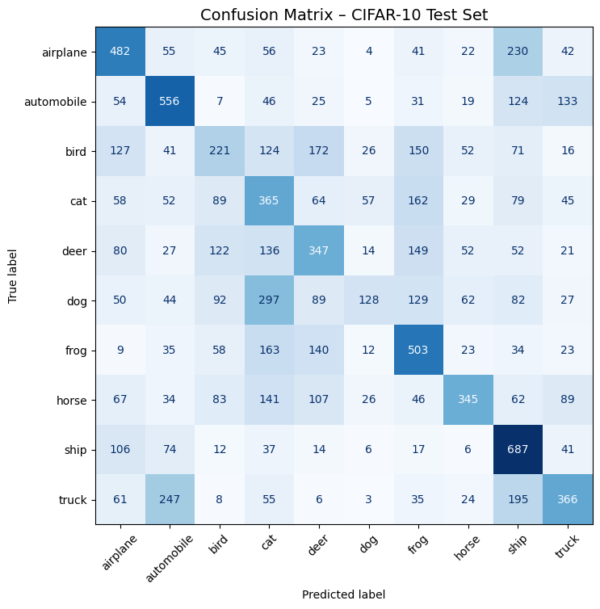

```
 *** Classification Report – CIFAR-10 Test Set ***

              precision    recall  f1-score   support

    airplane       0.44      0.48      0.46      1000
  automobile       0.48      0.56      0.51      1000
        bird       0.30      0.22      0.25      1000
         cat       0.26      0.36      0.30      1000
        deer       0.35      0.35      0.35      1000
         dog       0.46      0.13      0.20      1000
        frog       0.40      0.50      0.44      1000
       horse       0.54      0.34      0.42      1000
        ship       0.43      0.69      0.53      1000
       truck       0.46      0.37      0.41      1000

    accuracy                           0.40     10000
   macro avg       0.41      0.40      0.39     10000
weighted avg       0.41      0.40      0.39     10000
```

```python
# --------------------------------------------------------------
# *** CIFAR-10 Model Evaluation: Accuracy, Confusion Matrix & Classification Report ***
# --------------------------------------------------------------

from sklearn.metrics import (
    confusion_matrix,
    ConfusionMatrixDisplay,
    accuracy_score,
    classification_report
)
import matplotlib.pyplot as plt
import torch

# --------------------------------------------------------------
# *** Switch Model to Evaluation Mode ***
# --------------------------------------------------------------
deep_model_tanh.eval()

# --------------------------------------------------------------
# *** Collect Predictions and True Labels ***
# --------------------------------------------------------------
all_preds = []
all_labels = []

with torch.no_grad():
    for images, labels in test_loader:
        images = images.to(device)
        labels = labels.to(device)

        outputs = deep_model_tanh(images)
        _, predicted = torch.max(outputs, 1)

        all_preds.extend(predicted.cpu().numpy())
        all_labels.extend(labels.cpu().numpy())

# --------------------------------------------------------------
# *** Compute Test Accuracy ***
# --------------------------------------------------------------
test_accuracy = accuracy_score(all_labels, all_preds)
test_f1 = f1_score(all_labels, all_preds)
test_recall = recall_score(all_labels, all_preds)
print(f"\n Test Accuracy: {test_accuracy:.4f}")
print(f"\n Test Recall : {test_recall}")
print(f"\n Test f1 : {test_f1}")

# --------------------------------------------------------------
# *** Confusion Matrix Visualization ***
# --------------------------------------------------------------
cm = confusion_matrix(all_labels, all_preds)
disp = ConfusionMatrixDisplay(confusion_matrix=cm, display_labels=class_names)

fig, ax = plt.subplots(figsize=(10, 8))
disp.plot(ax=ax, cmap='Blues', xticks_rotation=45, colorbar=False)
plt.title("Confusion Matrix – CIFAR-10 Test Set", fontsize=14)
plt.show()

# --------------------------------------------------------------
# *** Detailed Classification Report ***
# --------------------------------------------------------------
report = classification_report(all_labels, all_preds, target_names=class_names)
print("\n *** Classification Report – CIFAR-10 Test Set ***\n")
print(report)
```